# Lab 8: Introduction to machine learning for Bioinformatics

Caroline Mackey (A15522472)

10/24/2021

## 1. PCA of UK food data

### Part A: Data Import

First, import data from provided link.

```r
url <- "https://tinyurl.com/UK-foods"
x <- read.csv(url)
```

> **Q1.** How many rows and columns are in your new data frame named x? What R functions could you use to answer this questions?

```r
dim(x)
```

```
## [1] 17  5
```

### Part B: Checking My Data

Use head() function to check data.

```r
# Preview the first 6 rows:
head(x)
```

```
##                X England Wales Scotland N.Ireland
## 1         Cheese     105   103      103        66
## 2  Carcass_meat      245   227      242       267
## 3    Other_meat      685   803      750       586
## 4           Fish     147   160      122        93
## 5 Fats_and_oils      193   235      184       209
## 6         Sugars     156   175      147       139
```

Correct row names so that column 1 values are the row names.

```r
# Note how the minus indexing works
rownames(x) <- x[,1]
x <- x[,-1]
head(x)
```

```
##                England Wales Scotland N.Ireland
## Cheese             105   103      103        66
## Carcass_meat       245   227      242       267
## Other_meat         685   803      750       586
## Fish               147   160      122        93
## Fats_and_oils      193   235      184       209
## Sugars             156   175      147       139
```

Check dimensions

```r
dim(x)
```

```
## [1] 17  4
```

Alternatively, correct row-names when reading the data file.

```r
# Using variable y to show that it is different from our previous attempt of using variable x.
url <- "https://tinyurl.com/UK-foods"
y <- read.csv(url, row.names=1)
head(y)
```

```
##                England Wales Scotland N.Ireland
## Cheese             105   103      103        66
## Carcass_meat       245   227      242       267
## Other_meat         685   803      750       586
## Fish               147   160      122        93
## Fats_and_oils      193   235      184       209
## Sugars             156   175      147       139
```

> **Q2.** Which approach to solving the ‘row-names problem’ mentioned above do you prefer and why? Is one approach more robust than another under certain circumstances?

> **A2.** I prefer using the second approach of solving the ‘row-names problem,’ since it corrects the problem as we call the data set. Since we’re correcting the problem as we call teh data set, it will be correct each time we use it. This requires fewer lines of code, and makes our code more robust.

### Part C: Spotting major differences & trends

Generate a preliminary barplot to visualize the data.

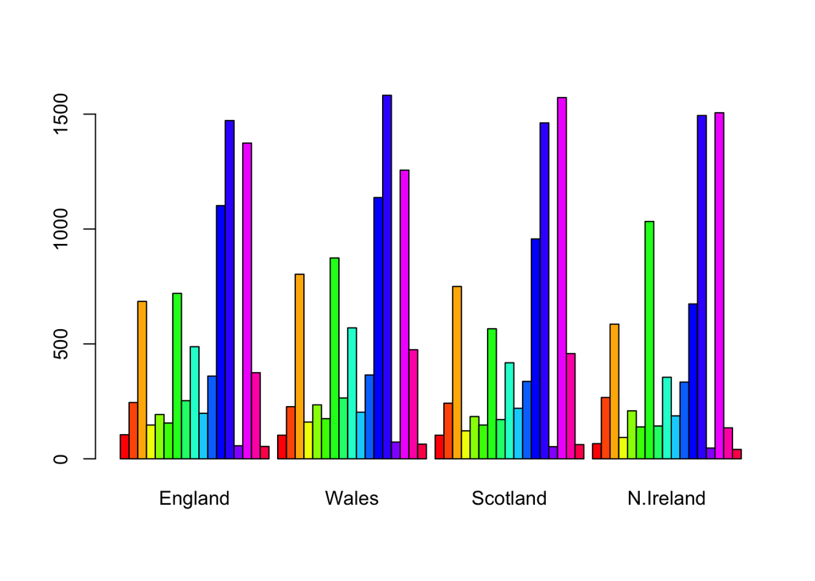

```r
barplot(as.matrix(x),
        beside=T,
        col=rainbow(nrow(x)))
```

> **Q3.** Changing what optional argument in the above barplot() function results in the provided plot?

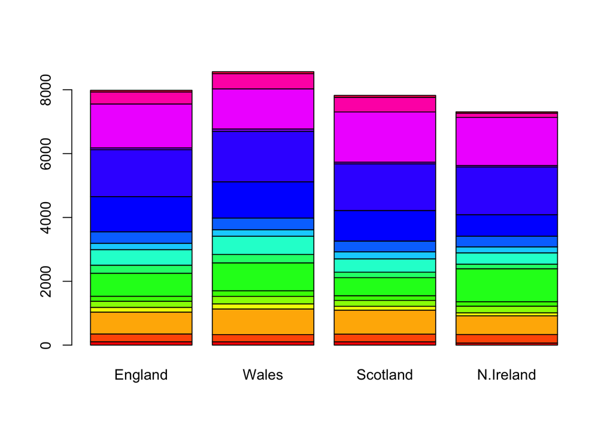

```r
barplot(as.matrix(x),
        beside=F,
        col=rainbow(nrow(x)),
        )
```

> **A3.** As shown above, setting beside to F rather than T created the desired bar chart.

> **Q4.** Question 4 was not included on our lab worksheet…

> **Q5.** Generating all pairwise plots may help somewhat. Can you make sense of the following code and resulting figure? What does it mean if a given point lies on the diagonal for a given plot?

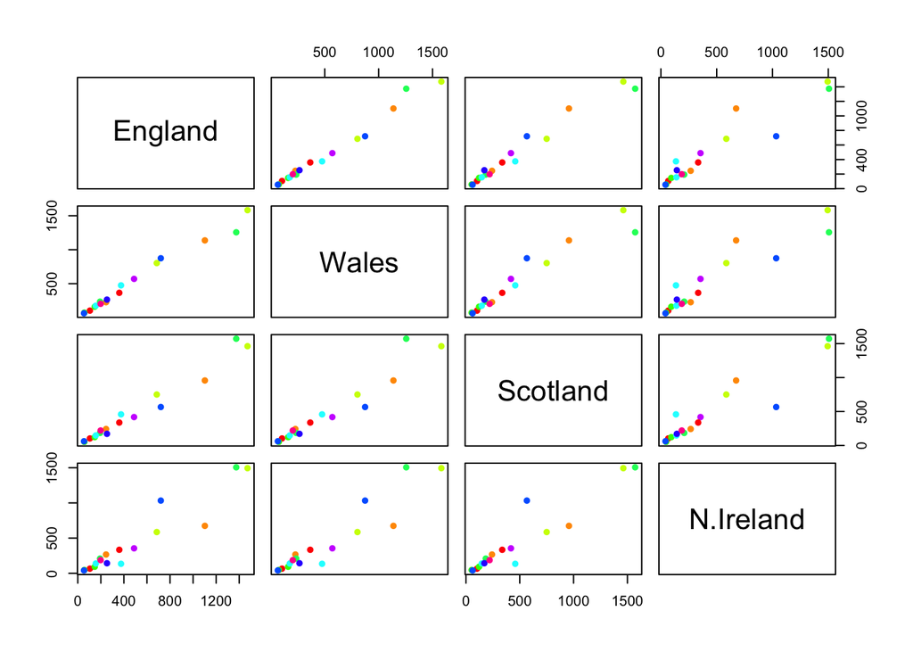

```r
pairs(x,
      col=rainbow(10),
      pch=16,
      )
```

> **A5.** The graphs above show all possible combinations of our 4 countries. The points on the plot represent our 17 categories of foods, with the x coordinate representing the consumption in the first country, and the y coordinate representing the consumption on the second country. If a point lies on the diagonal for a given plot, it suggests that people in those 2 countries eat a similar amount of that type of food.

> **Q6.** What is the main differences between N. Ireland and the other countries of the UK in terms of this data-set?

> **A6.** N. Ireland has a couple of outliers that the other three countries do not have. On the graph, the most significant outliers appear to be the blue and orange colored data points, as they don’t fall as close to the diagonal line. Right now, we cannot easily tell which food categories these data points represent.

### Part D: PCA to the Rescue

Perform PCA.

```r
# Use the prcomp() PCA function.
# Transform x so that observations are rows and variables are be columns.
pca <- prcomp( t(x) )
summary (pca)
```

```
## Importance of components:
##                             PC1      PC2      PC3       PC4
## Standard deviation     324.1502 212.7478 73.87622 4.189e-14
## Proportion of Variance   0.6744   0.2905  0.03503 0.000e+00
## Cumulative Proportion    0.6744   0.9650  1.00000 1.000e+00
```

> **Q7.** Complete the code below to generate a plot of PC1 vs PC2. The second line adds text labels over the data points.

> **A7.** See below.

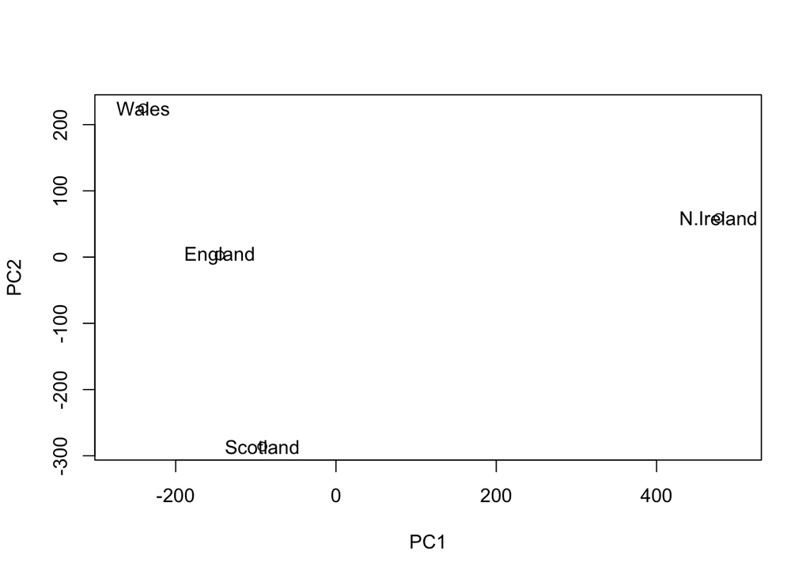

```r
# Plot PC1 vs PC2
plot (pca$x[,1], pca$x[,2],
      xlab="PC1", ylab="PC2",
      xlim=c(-270,500))
text (pca$x[,1], pca$x[,2],
      colnames(x))
```

> **Q8.** Customize your plot so that the colors of the country names match the colors in our UK and Ireland map and table at start of this document.

> **A8.** See below.

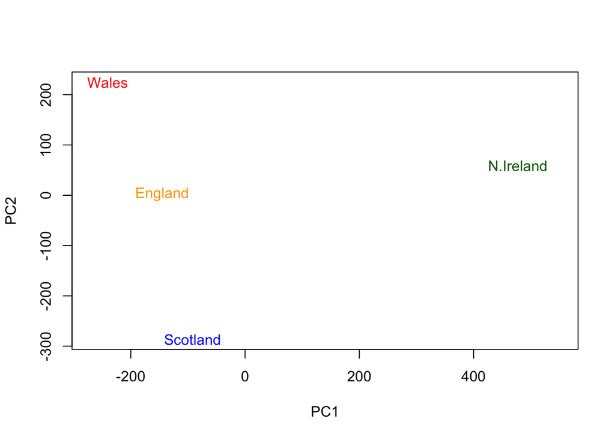

```r
# Plot PC1 vs PC2 with customized colors.

# Make vector of desired colors.
country_cols <- c("orange", "red", "blue", "dark green")

plot (pca$x[,1], pca$x[,2],
      xlab="PC1", ylab="PC2",
      # Change xlim so that N. Ireland text isn't cut off:
      xlim=c(-270,550),
      # Remove data point dots to make text more readable:
      col=NA)
text (pca$x[,1], pca$x[,2],
      colnames(x),
      # Assign colors using vector from earlier.
      col=country_cols)
```

First, calculate the amount of variation in the original data each PC accounts for using square of pca$sdev (standard deviation).

```r
v <- round( pca$sdev^2/sum(pca$sdev^2) * 100 )
v
```

```
## [1] 67 29  4  0
```

```r
# Or the second row here...
z <- summary(pca)
z$importance
```

```
##                              PC1       PC2      PC3          PC4
## Standard deviation     324.15019 212.74780 73.87622 4.188568e-14
## Proportion of Variance   0.67444   0.29052  0.03503 0.000000e+00
## Cumulative Proportion    0.67444   0.96497  1.00000 1.000000e+00
```

Summarize in a plot of the variances (eigenvalues) with respect to the principal component number (eigenvector number).

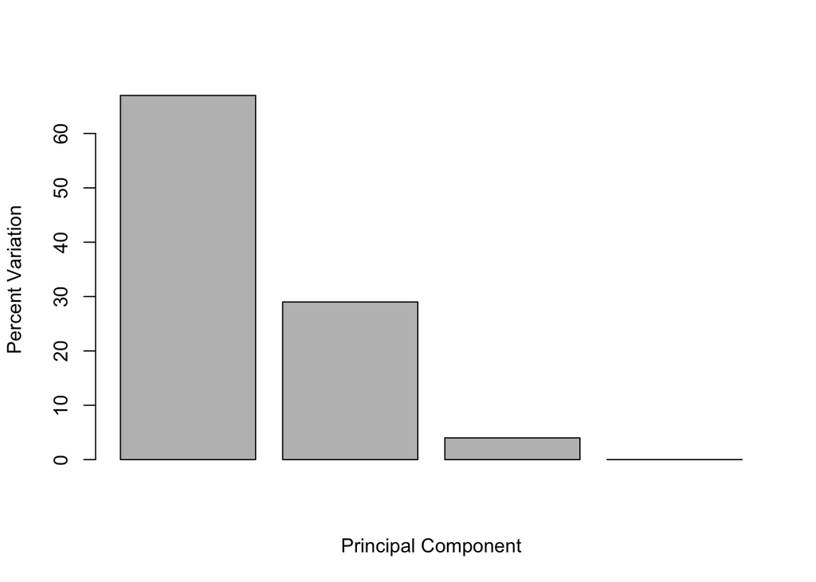

```r
barplot (v,
         xlab="Principal Component",
         ylab="Percent Variation")
```